# Profiling de un clustering sobre datos mixtos

Análisis de segmentación y caracterización de clústeres

Author

Sergi Ramirez Mitjans

# 1 Objetivo

Este documento realiza el **profiling completo de un clustering jerárquico** aplicado sobre una base de datos con variables mixtas (numéricas y categóricas). El flujo sigue estas fases:

1. **Carga y preparación de los datos**.
2. **Cálculo de distancias de Gower** para datos mixtos.
3. **Clustering jerárquico** con criterio Ward.
4. **Asignación de individuos a clústeres**.
5. **Fase 1 de profiling**: detección de variables significativas.
6. **Cálculo de centroides/modas por clúster**.
7. **Fase 2 de profiling**: significación de modalidades mediante enfoque de Lebart.

# 2 Vista general de los datos

## 2.1 Dimensiones y estructura

**Mostrar código**

```r
list(
  dimensiones = dim(dades),
  variables_numericas = varNum,
  variables_categoricas = varCat
)
```

```
$dimensiones
[1] 3900   18

$variables_numericas
[1] "Age"                   "Purchase.Amount..USD." "Review.Rating"
[4] "Previous.Purchases"

$variables_categoricas
 [1] "Gender"                 "Item.Purchased"         "Category"
 [4] "Location"               "Size"                   "Color"
 [7] "Season"                 "Subscription.Status"    "Shipping.Type"
[10] "Discount.Applied"       "Promo.Code.Used"        "Payment.Method"
[13] "Frequency.of.Purchases"
```

## 2.2 Primeras filas

**Mostrar código**

```r
head(dades)
```

|  | Customer.ID | Age | Gender | Item.Purchased | Category | Purchase.Amount..USD. | Location | Size | Color | Season | Review.Rating | Subscription.Status | Shipping.Type | Discount.Applied | Promo.Code.Used | Previous.Purchases | Payment.Method | Frequency.of.Purchases |
| --- | --- | --- | --- | --- | --- | --- | --- | --- | --- | --- | --- | --- | --- | --- | --- | --- | --- | --- |
| 1 | 1 | 55 | Male | Blouse | Clothing | 53 | Kentucky | L | Gray | Winter | 3.1 | Yes | Express | Yes | Yes | 14 | Venmo | Fortnightly |
| 2 | 2 | 19 | Male | Sweater | Clothing | 64 | Maine | L | Maroon | Winter | 3.1 | Yes | Express | Yes | Yes | 2 | Cash | Fortnightly |
| 3 | 3 | 50 | Male | Jeans | Clothing | 73 | Massachusetts | S | Maroon | Spring | 3.1 | Yes | Free Shipping | Yes | Yes | 23 | Credit Card | Weekly |
| 4 | 4 | 21 | Male | Sandals | Footwear | 90 | Rhode Island | M | Maroon | Spring | 3.5 | Yes | Next Day Air | Yes | Yes | 49 | PayPal | Weekly |
| 5 | 5 | 45 | Male | Blouse | Clothing | 49 | Oregon | M | Turquoise | Spring | 2.7 | Yes | Free Shipping | Yes | Yes | 31 | PayPal | Annually |
| 6 | 6 | 46 | Male | Sneakers | Footwear | 20 | Wyoming | M | White | Summer | 2.9 | Yes | Standard | Yes | Yes | 14 | Venmo | Weekly |

## 2.3 Resumen descriptivo

**Mostrar código**

```r
summary(dades)
```

```
  Customer.ID          Age           Gender     Item.Purchased
 Min.   :   1.0   Min.   :18.00   Female:1248   Blouse : 171
 1st Qu.: 975.8   1st Qu.:31.00   Male  :2652   Jewelry: 171
 Median :1950.5   Median :44.00                 Pants  : 171
 Mean   :1950.5   Mean   :44.07                 Shirt  : 169
 3rd Qu.:2925.2   3rd Qu.:57.00                 Dress  : 166
 Max.   :3900.0   Max.   :70.00                 Sweater: 164
                                                (Other):2888
        Category    Purchase.Amount..USD.       Location    Size
 Accessories:1240   Min.   : 20.00        Montana   :  96   L :1053
 Clothing   :1737   1st Qu.: 39.00        California:  95   M :1755
 Footwear   : 599   Median : 60.00        Idaho     :  93   S : 663
 Outerwear  : 324   Mean   : 59.76        Illinois  :  92   XL: 429
                    3rd Qu.: 81.00        Alabama   :  89
                    Max.   :100.00        Minnesota :  88
                                          (Other)   :3347
     Color         Season    Review.Rating  Subscription.Status
 Olive  : 177   Fall  :975   Min.   :2.50   No :2847
 Yellow : 174   Spring:999   1st Qu.:3.10   Yes:1053
 Silver : 173   Summer:955   Median :3.70
 Teal   : 172   Winter:971   Mean   :3.75
 Green  : 169                3rd Qu.:4.40
 Black  : 167                Max.   :5.00
 (Other):2868
        Shipping.Type Discount.Applied Promo.Code.Used Previous.Purchases
 2-Day Shipping:627   No :2223         No :2223        Min.   : 1.00
 Express       :646   Yes:1677         Yes:1677        1st Qu.:13.00
 Free Shipping :675                                    Median :25.00
 Next Day Air  :648                                    Mean   :25.35
 Standard      :654                                    3rd Qu.:38.00
 Store Pickup  :650                                    Max.   :50.00

       Payment.Method    Frequency.of.Purchases
 Bank Transfer:612    Annually      :572
 Cash         :670    Bi-Weekly     :547
 Credit Card  :671    Every 3 Months:584
 Debit Card   :636    Fortnightly   :542
 PayPal       :677    Monthly       :553
 Venmo        :634    Quarterly     :563
                      Weekly        :539
```

# 3 Clustering jerárquico sobre datos mixtos

## 3.1 Cálculo de distancias de Gower

**Mostrar código**

```r
distancias <- cluster::daisy(dades, metric = "gower")
distancias2 <- distancias^2

cat("Número de observaciones:", nrow(dades), "\n")
```

```
Número de observaciones: 3900
```

**Mostrar código**

```r
cat("Número de distancias almacenadas:", length(distancias), "\n")
```

```
Número de distancias almacenadas: 7603050
```

## 3.2 Construcción del dendrograma

**Mostrar código**

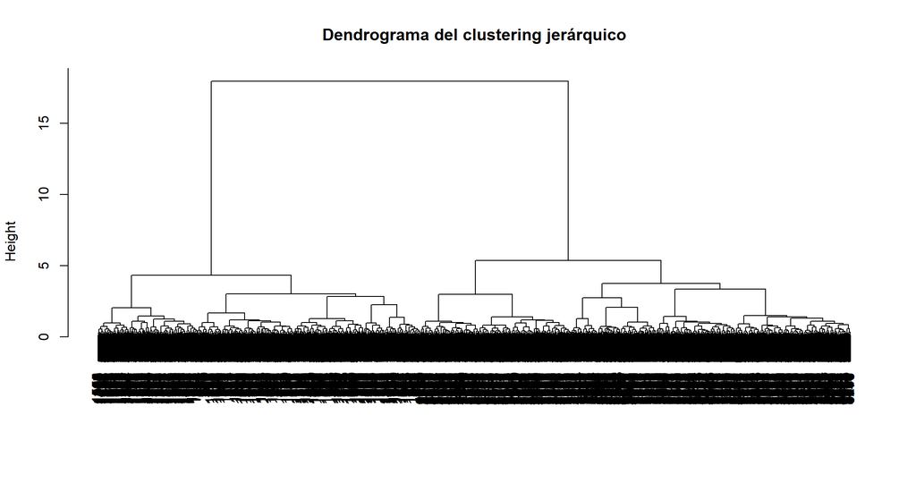

```r
hc <- hclust(distancias2, method = "ward.D2")
plot(hc, main = "Dendrograma del clustering jerárquico", xlab = "", sub = "")
```

## 3.3 Dendrograma coloreado para k = 2

**Mostrar código**

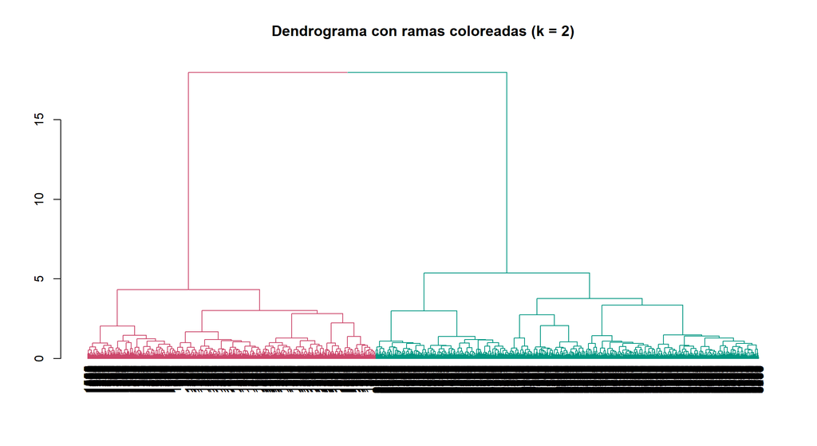

```r
as.dendrogram(hc) |>
  set("branches_k_color", k = 2) |>
  plot(main = "Dendrograma con ramas coloreadas (k = 2)")
```

## 3.4 Corte del árbol y asignación de clúster

**Mostrar código**

```r
dades$cluster <- as.factor(cutree(hc, k = 2))

table(dades$cluster)
```

```
   1    2
1675 2225
```

## 3.5 Calidad interna básica del clustering

**Mostrar código**

```r
fpc::cluster.stats(distancias2, clustering = as.numeric(dades$cluster))
```

```
$n
[1] 3900

$cluster.number
[1] 2

$cluster.size
[1] 1675 2225

$min.cluster.size
[1] 1675

$noisen
[1] 0

$diameter
[1] 0.7302687 0.7458370

$average.distance
[1] 0.2839729 0.2876841

$median.distance
[1] 0.2819710 0.2854016

$separation
[1] 0.07820618 0.07820618

$average.toother
[1] 0.4939339 0.4939339

$separation.matrix
           [,1]       [,2]
[1,] 0.00000000 0.07820618
[2,] 0.07820618 0.00000000

$ave.between.matrix
          [,1]      [,2]
[1,] 0.0000000 0.4939339
[2,] 0.4939339 0.0000000

```

[output cut: 51 more lines]

```

$cwidegap
[1] 0.1131343 0.1221295

$widestgap
[1] 0.1221295

$sindex
[1] 0.1153038

$corrected.rand
NULL

$vi
NULL
```

# 4 Profiling

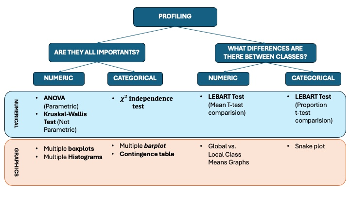

## 4.1 Fase 1 del profiling: variables que diferencian los grupos

En esta fase se identifican las variables que discriminan significativamente entre clústeres.

- Para variables **numéricas**:
  - Se evalúa normalidad con **Shapiro-Wilk**.
  - Si hay normalidad, se aplica **ANOVA**.
  - Si no hay normalidad, se aplica **Kruskal-Wallis**.
- Para variables **categóricas**:
  - Se aplica **Chi-cuadrado de independencia**.

**Mostrar código**

```r
columnasValidar <- setdiff(colnames(dades), c("Customer.ID", "cluster"))
variablesPasanFase1 <- c()
resultadosFase1 <- list()

for (cV in columnasValidar) {
  clase_var <- class(dades[[cV]])[1]

  # =====================
  # VARIABLES NUMÉRICAS
  # =====================
  if (clase_var %in% c("integer", "numeric")) {
    shapiro_ok <- FALSE
    p_shapiro <- NA_real_
    metodo <- NA_character_
    p_valor <- NA_real_
    detalle <- NULL

    # Shapiro falla si hay demasiados datos o valores constantes; controlamos eso.
    sh <- tryCatch(shapiro.test(dades[[cV]]), error = function(e) NULL)
    if (!is.null(sh)) {
      p_shapiro <- sh$p.value
      shapiro_ok <- p_shapiro > 0.05
    }

    if (!is.na(p_shapiro) && shapiro_ok) {
      test_obj <- aov(dades[[cV]] ~ dades$cluster)
      detalle <- summary(test_obj)
      p_valor <- detalle[[1]][["Pr(>F)"]][1]
      metodo <- "ANOVA"
    } else {
      test_obj <- kruskal.test(dades[[cV]] ~ dades$cluster)
      detalle <- test_obj
      p_valor <- test_obj$p.value
      metodo <- "Kruskal-Wallis"
    }

    if (!is.na(p_valor) && p_valor <= 0.05) {
      variablesPasanFase1 <- c(variablesPasanFase1, cV)
    }

    resultadosFase1[[cV]] <- list(
      tipo = "Numérica",
      metodo = metodo,
      p_shapiro = p_shapiro,
      p_valor = p_valor,
      detalle = detalle
    )
  }

  # =======================
  # VARIABLES CATEGÓRICAS
  # =======================
  if (clase_var %in% c("factor", "character")) {
    test_obj <- suppressWarnings(chisq.test(dades[[cV]], dades$cluster))
    p_valor <- test_obj$p.value

    if (!is.na(p_valor) && p_valor <= 0.05) {
      variablesPasanFase1 <- c(variablesPasanFase1, cV)
    }

    resultadosFase1[[cV]] <- list(
      tipo = "Categórica",
      metodo = "Chi-cuadrado",
      p_valor = p_valor,
      detalle = test_obj
    )
  }
}

variablesPasanFase1 <- unique(variablesPasanFase1)
variablesPasanFase1
```

```
[1] "Gender"              "Subscription.Status" "Discount.Applied"
[4] "Promo.Code.Used"
```

### 4.1.1 Tabla resumen de significación

**Mostrar código**

```r
tablaFase1 <- dplyr::bind_rows(lapply(names(resultadosFase1), function(v) {
  x <- resultadosFase1[[v]]
  data.frame(
    variable = v,
    tipo = x$tipo,
    metodo = x$metodo,
    p_shapiro = ifelse(is.null(x$p_shapiro), NA, x$p_shapiro),
    p_valor = x$p_valor,
    significativa = ifelse(!is.na(x$p_valor) & x$p_valor <= 0.05, "Sí", "No")
  )
}))

tablaFase1 <- tablaFase1 |>
  arrange(tipo, p_valor)

tablaFase1
```

| variable | tipo | metodo | p_shapiro | p_valor | significativa |
| --- | --- | --- | --- | --- | --- |
| Subscription.Status | Categórica | Chi-cuadrado | NA | 0.000000e+00 | Sí |
| Discount.Applied | Categórica | Chi-cuadrado | NA | 0.000000e+00 | Sí |
| Promo.Code.Used | Categórica | Chi-cuadrado | NA | 0.000000e+00 | Sí |
| Gender | Categórica | Chi-cuadrado | NA | 7.499847e-302 | Sí |
| Item.Purchased | Categórica | Chi-cuadrado | NA | 1.237391e-01 | No |
| Season | Categórica | Chi-cuadrado | NA | 4.172943e-01 | No |
| Size | Categórica | Chi-cuadrado | NA | 4.796675e-01 | No |
| Payment.Method | Categórica | Chi-cuadrado | NA | 5.348886e-01 | No |
| Location | Categórica | Chi-cuadrado | NA | 5.505462e-01 | No |
| Shipping.Type | Categórica | Chi-cuadrado | NA | 5.846760e-01 | No |

[output cut: 7 more lines]

## 4.2 Visualización de variables del profiling

### 4.2.1 Variables numéricas

**Mostrar código**

```r
vars_num_a_graficar <- columnasValidar[sapply(dades[columnasValidar], function(x) class(x)[1] %in% c("integer", "numeric"))]
vars_num_a_graficar
```

```
[1] "Age"                   "Purchase.Amount..USD." "Review.Rating"
[4] "Previous.Purchases"
```

**Mostrar código**

```r
for (cV in vars_num_a_graficar) {
  cat("### ", cV, "\n\n", sep = "")

  graficoBoxplot <- ggpubr::ggboxplot(dades, "cluster", cV, fill = "cluster")
  graficoHistograma <- ggpubr::gghistogram(
    dades, x = cV,
    add = "mean", rug = TRUE,
    color = "cluster", fill = "cluster"
  )

  grafico <- ggpubr::ggarrange(
    graficoBoxplot, graficoHistograma,
    heights = c(2, 0.7),
    ncol = 2, nrow = 1, align = "v"
  )

  print(grafico)
  cat("\n")
}
```

### 4.2.2 Age

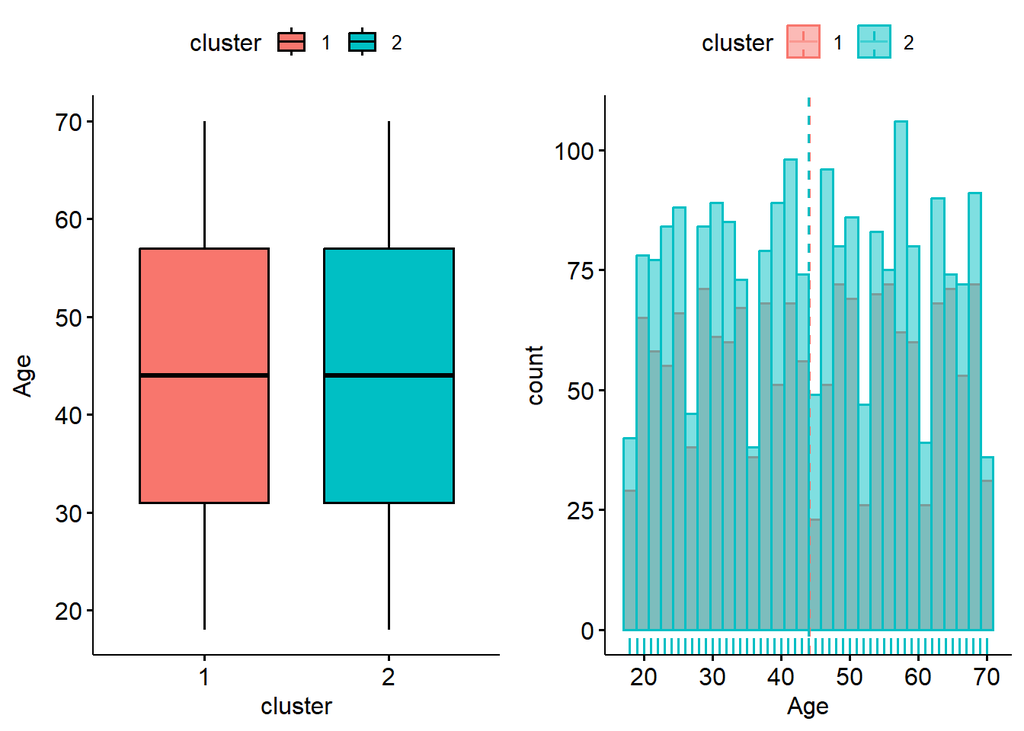

### Purchase.Amount..USD.

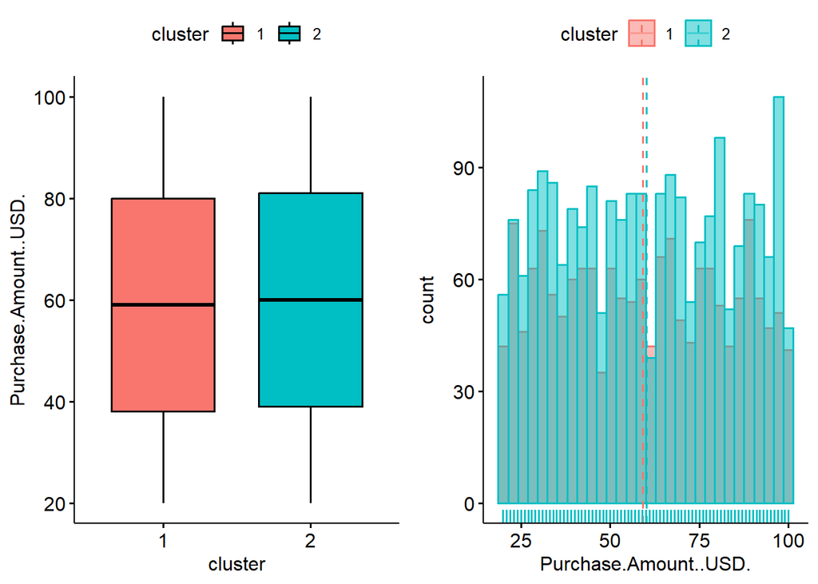

### Review.Rating

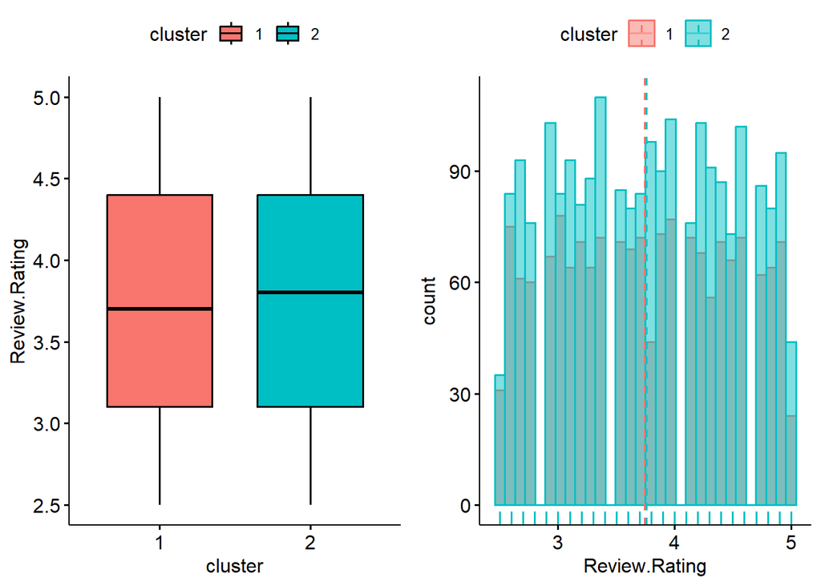

### Previous.Purchases

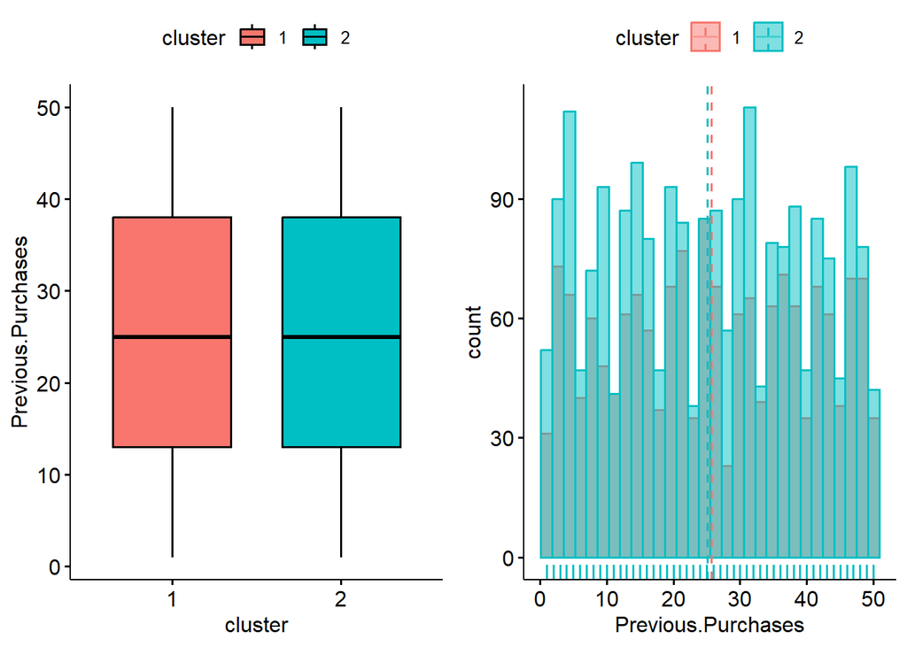

### 4.2.3 Variables categóricas

**Mostrar código**

```r
vars_cat_a_graficar <- columnasValidar[sapply(dades[columnasValidar], function(x) class(x)[1] %in% c("factor", "character"))]
vars_cat_a_graficar
```

```
 [1] "Gender"                 "Item.Purchased"         "Category"
 [4] "Location"               "Size"                   "Color"
 [7] "Season"                 "Subscription.Status"    "Shipping.Type"
[10] "Discount.Applied"       "Promo.Code.Used"        "Payment.Method"
[13] "Frequency.of.Purchases"
```

**Mostrar código**

```r
for (cV in vars_cat_a_graficar) {
  cat("### ", cV, "\n\n", sep = "")

  tabla <- data.frame(table(dades[[cV]], dades$cluster))
  colnames(tabla) <- c("modalidad", "cluster", "Freq")

  grafico <- ggplot(tabla, aes(x = modalidad, y = Freq, fill = cluster)) +
    geom_bar(stat = "identity", position = "dodge") +
    labs(title = paste("Distribución de", cV, "por clúster"), x = cV, y = "Frecuencia") +
    theme_minimal() +
    theme(axis.text.x = element_text(angle = 45, hjust = 1))

  print(grafico)
  cat("\n")
}
```

### 4.2.4 Gender

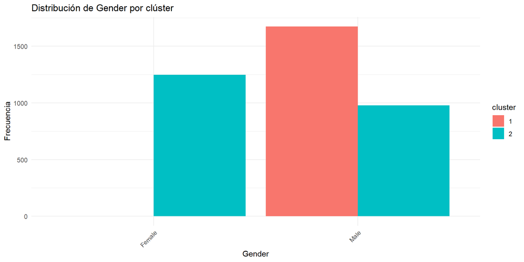

### Item.Purchased

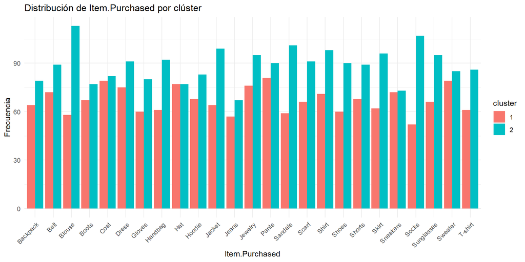

### Category

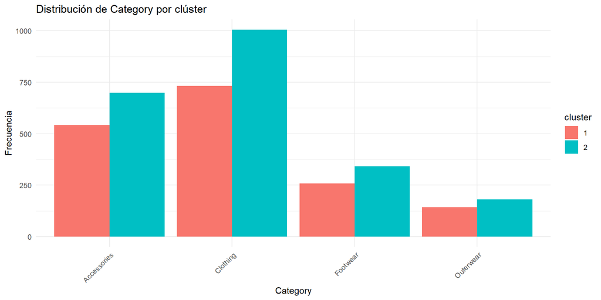

### Location

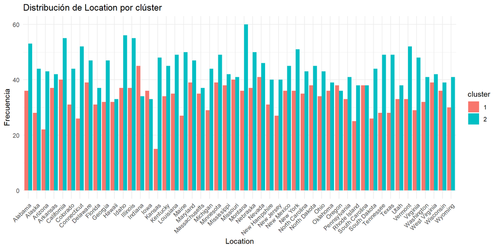

### Size

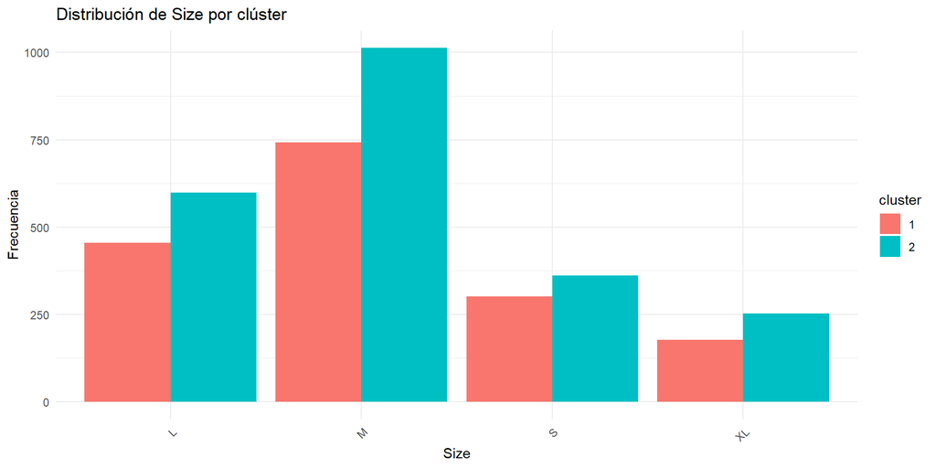

### Color

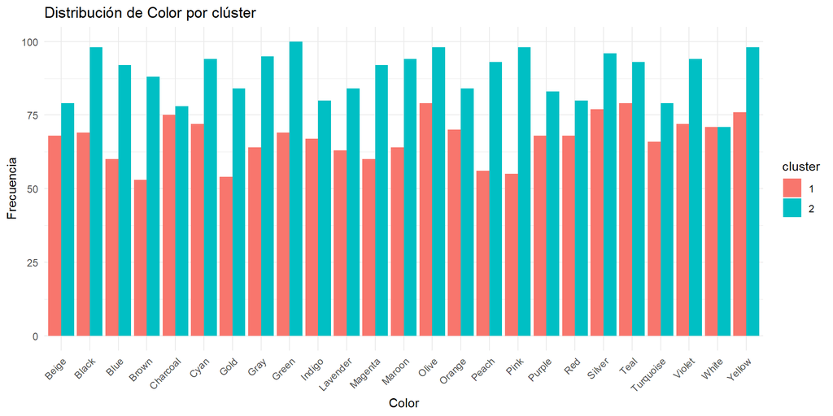

### Season

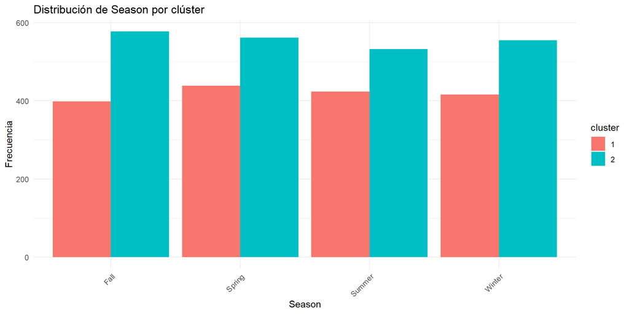

### Subscription.Status

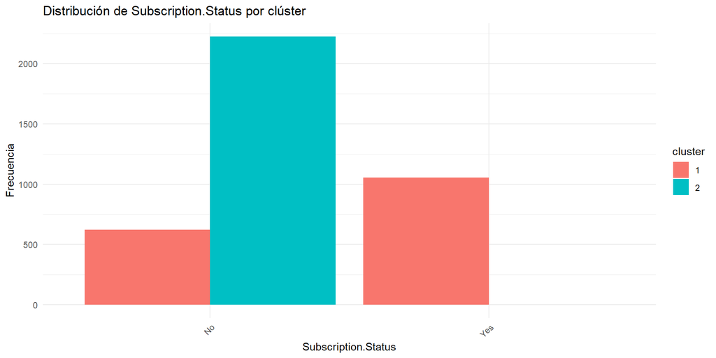

### Shipping.Type

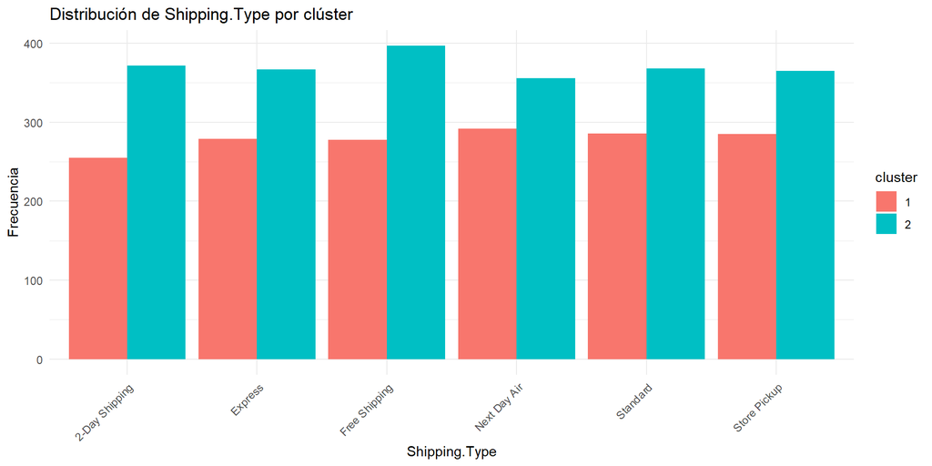

### Discount.Applied

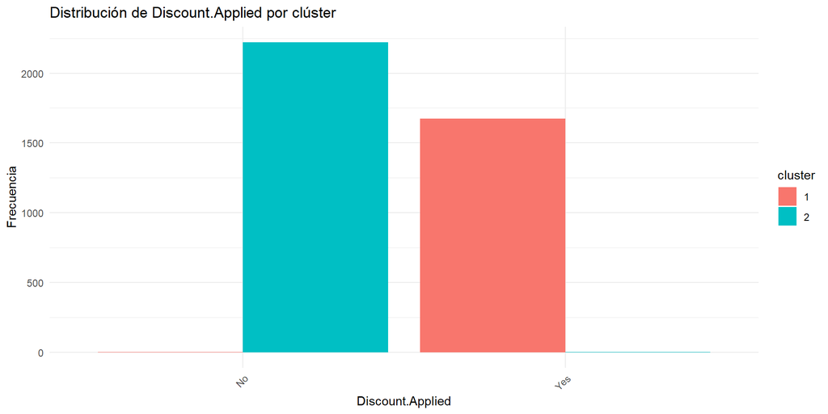

### Promo.Code.Used

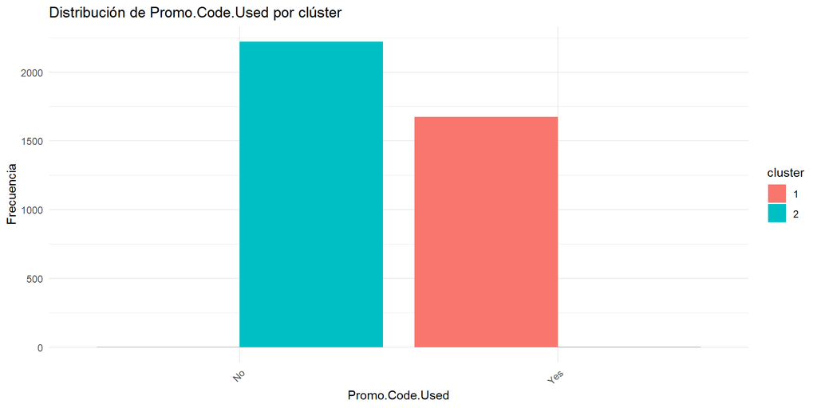

### Payment.Method

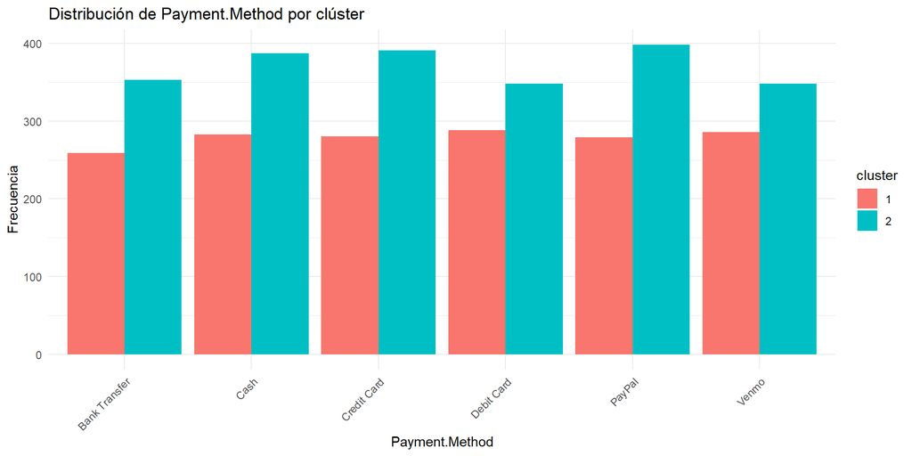

### Frequency.of.Purchases

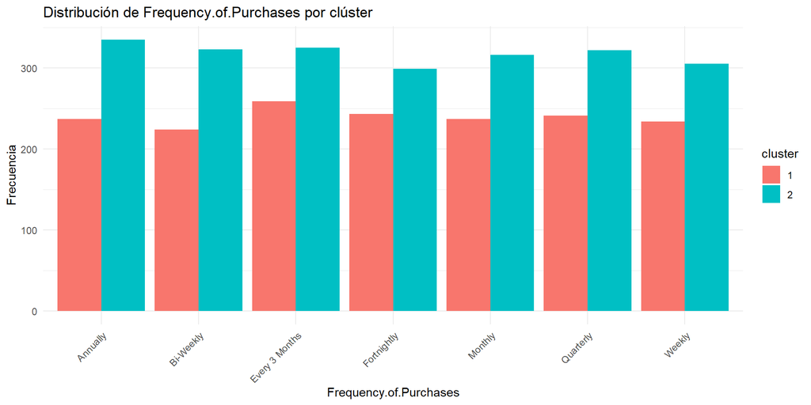

## 4.3 Centroides y modas por clúster

### 4.3.1 Variables numéricas significativas

**Mostrar código**

```r
datosAnalizarNum <- dades[, intersect(variablesPasanFase1, varNum), drop = FALSE]

if (ncol(datosAnalizarNum) > 0) {
  psych::describeBy(datosAnalizarNum, dades$cluster, mat = TRUE)
} else {
  cat("No hay variables numéricas significativas en la fase 1.")
}
```

```
No hay variables numéricas significativas en la fase 1.
```

### 4.3.2 Variables categóricas significativas: moda por clúster

**Mostrar código**

```r
variablesAnalizarCAT <- intersect(variablesPasanFase1, varCat)
listaModa <- list()

if (length(variablesAnalizarCAT) > 0) {
  for (vC in variablesAnalizarCAT) {
    tabla <- data.frame(table(dades[[vC]], dades$cluster))
    colnames(tabla) <- c("modalidad", "cluster", "Freq")

    calModa <- tabla |>
      dplyr::group_by(cluster) |>
      dplyr::filter(Freq == max(Freq)) |>
      dplyr::select(modalidad, cluster, Freq) |>
      as.data.frame()

    listaModa[[vC]] <- calModa
  }

  listaModa
} else {
  cat("No hay variables categóricas significativas en la fase 1.")
}
```

```
$Gender
  modalidad cluster Freq
1      Male       1 1675
2    Female       2 1248

$Subscription.Status
  modalidad cluster Freq
1       Yes       1 1053
2        No       2 2225

$Discount.Applied
  modalidad cluster Freq
1       Yes       1 1674
2        No       2 2222

$Promo.Code.Used
  modalidad cluster Freq
1       Yes       1 1674
2        No       2 2222
```

## 4.4 Fase 2 del profiling: significación de modalidades (Lebart)

La segunda fase profundiza en la interpretación de los clústeres identificando:

- **Qué medias numéricas** caracterizan más a cada grupo.
- **Qué modalidades categóricas** están sobrerrepresentadas o infrarrepresentadas.

### 4.4.1 Resultados globales con `catdes()`

**Mostrar código**

```r
res_catdes <- FactoMineR::catdes(dades, num.var = ncol(dades))
res_catdes
```

```
Link between the cluster variable and the categorical variables (chi-square test)
=================================================================================
                          p.value df
Subscription.Status  0.000000e+00  1
Discount.Applied     0.000000e+00  1
Promo.Code.Used      0.000000e+00  1
Gender              2.066222e-302  1

Description of each cluster by the categories
=============================================
$`1`
                             Cla/Mod      Mod/Cla    Global     p.value
Promo.Code.Used=Yes      99.82110912  99.94029851 43.000000 0.000000000
Discount.Applied=Yes     99.82110912  99.94029851 43.000000 0.000000000
Subscription.Status=Yes 100.00000000  62.86567164 27.000000 0.000000000
Gender=Male              63.15987934 100.00000000 68.000000 0.000000000
Location=Indiana         56.96202532   2.68656716  2.025641 0.012006802
Item.Purchased=Blouse    33.91812865   3.46268657  4.384615 0.014098571
Item.Purchased=Socks     32.70440252   3.10447761  4.076923 0.007237583
Location=Kansas          23.80952381   0.89552239  1.615385 0.001587204
Promo.Code.Used=No        0.04498426   0.05970149 57.000000 0.000000000
Discount.Applied=No       0.04498426   0.05970149 57.000000 0.000000000
Subscription.Status=No   21.84755883  37.13432836 73.000000 0.000000000
Gender=Female             0.00000000   0.00000000 32.000000 0.000000000
                           v.test
Promo.Code.Used=Yes           Inf
Discount.Applied=Yes          Inf
Subscription.Status=Yes       Inf
Gender=Male                   Inf
Location=Indiana         2.511944
Item.Purchased=Blouse   -2.454742
Item.Purchased=Socks    -2.685710
Location=Kansas         -3.158248
Promo.Code.Used=No           -Inf
Discount.Applied=No          -Inf
Subscription.Status=No       -Inf
Gender=Female                -Inf

$`2`
                            Cla/Mod     Mod/Cla    Global     p.value    v.test
```

[output cut: 17 more lines]

```
Customer.ID 0.7341974       0

Description of each cluster by quantitative variables
=====================================================
$`1`
              v.test Mean in category Overall mean sd in category Overall sd
Customer.ID -53.5036          838.671       1950.5       484.5845   1125.833
            p.value
Customer.ID       0

$`2`
             v.test Mean in category Overall mean sd in category Overall sd
Customer.ID 53.5036         2787.495       1950.5       643.2368   1125.833
            p.value
Customer.ID       0
```

### 4.4.2 Gráfico de variables cuantitativas

**Mostrar código**

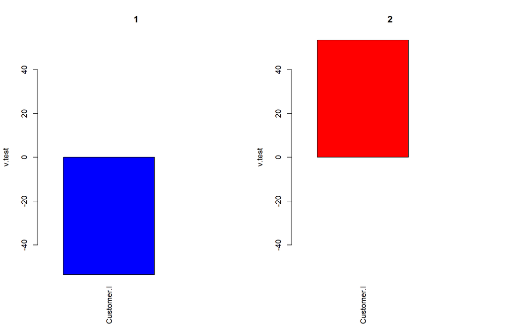

```r
plot(res_catdes, show = "quanti", col.upper = "red", col.lower = "blue",
     barplot = TRUE, cex.names = 1)
```

### 4.4.3 Gráfico de variables cualitativas

**Mostrar código**

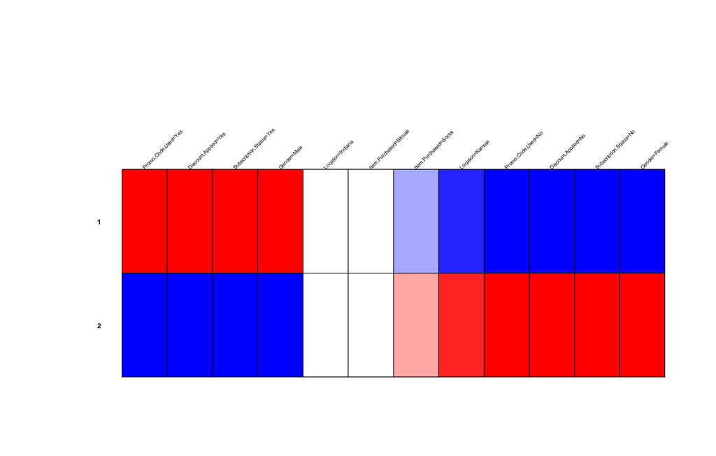

```r
plot(res_catdes, show = "quali", col.upper = "red", col.lower = "blue",
     barplot = FALSE, cex.names = 1.2)
```

### 4.4.4 Gráfico conjunto

**Mostrar código**

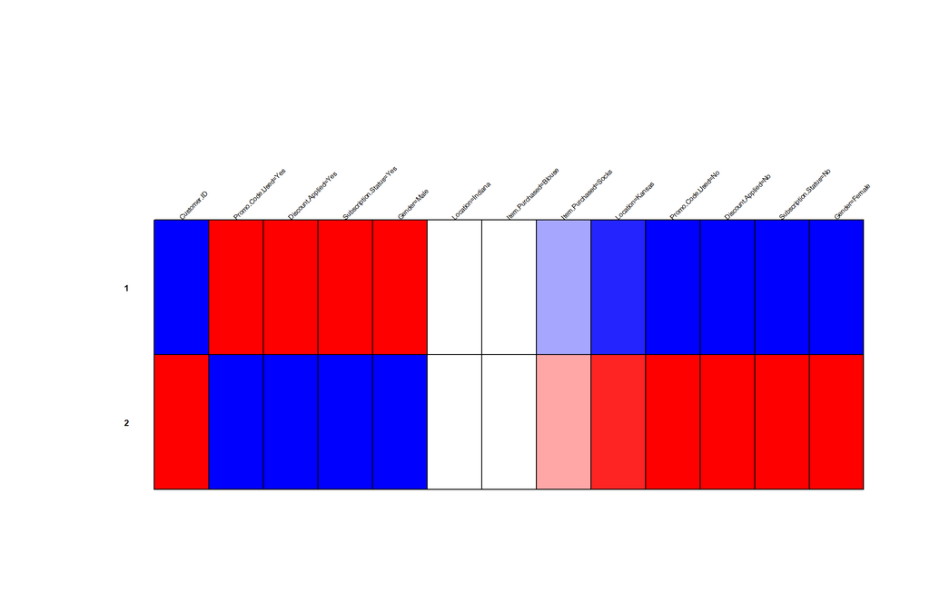

```r
plot(res_catdes, show = "all", col.upper = "red", col.lower = "blue",
     barplot = FALSE, cex.names = 1.2)
```

### 4.4.5 Test de Lebart para variables numéricas

**Mostrar código**

```r
dadesF <- FactoClass::Fac.Num(dades)
dades_num <- cbind(dadesF$numeric, dadesF$integer)
class_cluster <- dadesF$factor$cluster

if (ncol(dades_num) > 0) {
  prueba_num <- cluster.carac(
    dades_num, class_cluster,
    tipo.v = "co", v.lim = 1.96, neg = TRUE
  )
  prueba_num
} else {
  cat("No hay variables numéricas disponibles para el test de Lebart de medias.")
}
```

```
class: 1
            Test.Value Class.Mean Frequency Global.Mean
Customer.ID    -53.504    838.671      1675      1950.5
------------------------------------------------------------
class: 2
            Test.Value Class.Mean Frequency Global.Mean
Customer.ID     53.504   2787.495      2225      1950.5
```

### 4.4.6 Test de Lebart para variables categóricas

**Mostrar código**

```r
dades_cat <- dadesF$factor |> dplyr::select(-cluster)
class_cluster <- dadesF$factor$cluster

if (ncol(dades_cat) > 0) {
  prueba_cat <- cluster.carac(
    dades_cat, class_cluster,
    tipo.v = "ca", v.lim = 1.96, neg = FALSE
  )
  prueba_cat
} else {
  cat("No hay variables categóricas disponibles para el test de Lebart de proporciones.")
}
```

```
class: 1
                        Test.Value p.Value Class.Cat Cat.Class Global Weight
Gender.Male                    Inf   0.000      63.2     100.0   68.0   2652
Subscription.Status.Yes        Inf   0.000     100.0      62.9   27.0   1053
Discount.Applied.Yes           Inf   0.000      99.8      99.9   43.0   1677
Promo.Code.Used.Yes            Inf   0.000      99.8      99.9   43.0   1677
Location.Indiana             2.657   0.008      57.0       2.7    2.0     79
Item.Purchased.Hat           2.022   0.043      50.0       4.6    3.9    154
------------------------------------------------------------
class: 2
                       Test.Value p.Value Class.Cat Cat.Class Global Weight
Gender.Female                 Inf   0.000     100.0      56.1   32.0   1248
Subscription.Status.No        Inf   0.000      78.2     100.0   73.0   2847
Discount.Applied.No           Inf   0.000     100.0      99.9   57.0   2223
Promo.Code.Used.No            Inf   0.000     100.0      99.9   57.0   2223
Location.Kansas             3.251   0.001      76.2       2.2    1.6     63
Item.Purchased.Socks        2.840   0.005      67.3       4.8    4.1    159
Item.Purchased.Blouse       2.627   0.009      66.1       5.1    4.4    171
Color.Pink                  2.018   0.044      64.1       4.4    3.9    153
```

## 4.5 Conclusiones automáticas del profiling

### 4.5.1 Variables significativas detectadas

**Mostrar código**

```r
sig <- tablaFase1 |> dplyr::filter(significativa == "Sí")
sig
```

| variable | tipo | metodo | p_shapiro | p_valor | significativa |
| --- | --- | --- | --- | --- | --- |
| Subscription.Status | Categórica | Chi-cuadrado | NA | 0.000000e+00 | Sí |
| Discount.Applied | Categórica | Chi-cuadrado | NA | 0.000000e+00 | Sí |
| Promo.Code.Used | Categórica | Chi-cuadrado | NA | 0.000000e+00 | Sí |
| Gender | Categórica | Chi-cuadrado | NA | 7.499847e-302 | Sí |

### 4.5.2 Resumen interpretativo

**Mostrar código**

```r
cat("Número total de variables analizadas:", length(columnasValidar), "\n")
```

```
Número total de variables analizadas: 17
```

**Mostrar código**

```r
cat("Variables significativas en fase 1:", length(variablesPasanFase1), "\n\n")
```

```
Variables significativas en fase 1: 4
```

**Mostrar código**

```r
if (length(variablesPasanFase1) > 0) {
  cat("Variables que mejor diferencian los clústeres:\n")
  cat(paste0("- ", variablesPasanFase1, collapse = "\n"))
} else {
  cat("No se han detectado variables significativas con el umbral p <= 0.05.")
}
```

```
Variables que mejor diferencian los clústeres:
- Gender
- Subscription.Status
- Discount.Applied
- Promo.Code.Used
```

Aquesta web està creada por Dante Conti y Sergi Ramírez, (c) 2026